# 資料的視覺化與資料的比較

March 23, 2017

## R 的繪圖功能

- 基本功能
- ggplot2

## 基本功能

## 繪圖的要點

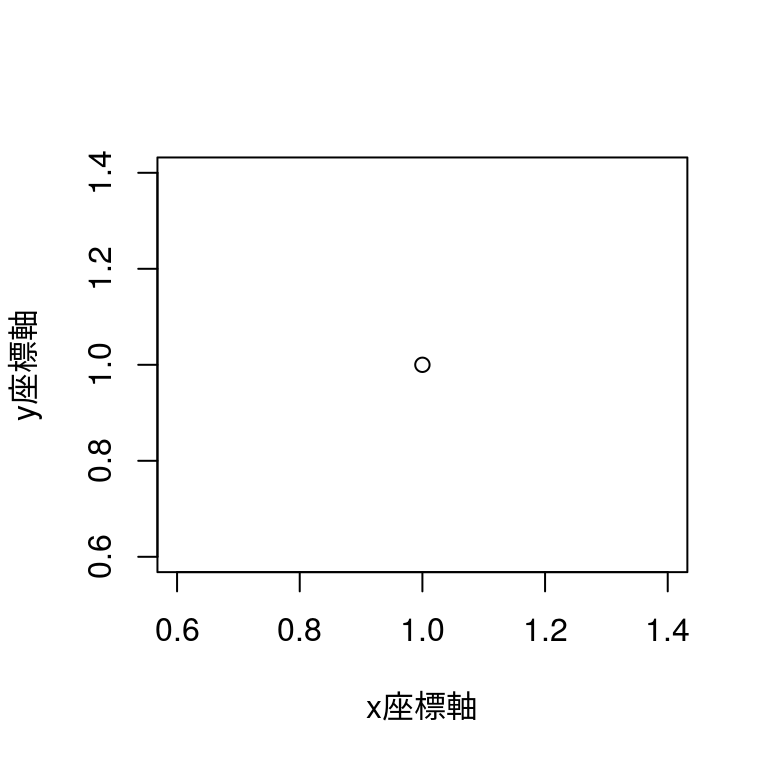

```r
if (grepl("darwin", R.version$os)) par(family = "STKaiti", bg = "transparent")
plot(x = 1, y = 1, type = "p", xlab = "x座標軸", ylab = "y座標軸")
```

- 繪圖的要點:
  - 完成主要的繪圖區域
    - 利用x 座標與y 座標定位點、線、面
  - 豐富其他說明文件
    - 例如：x 、y 座標軸與說明

## 基本API

- 操作對象多是以向量為主
- 高級繪圖函數: `plot`、`images`、`hist`…
- 低級繪圖函數: `points`、`lines`…

## 高級繪圖函數

- 會重新建立圖形的函數

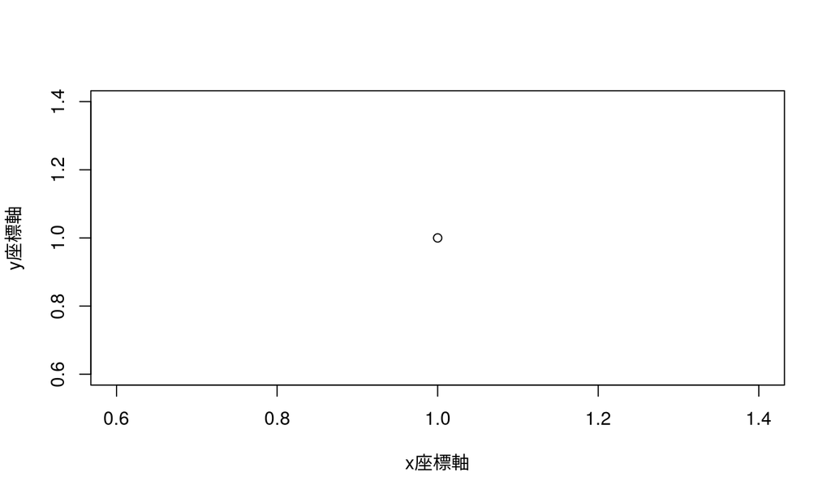

```r
plot(x = 1, y = 1, type = "p", xlab = "x座標軸", ylab = "y座標軸")
```

## 低級繪圖函數

- 會在原本的圖上作加註

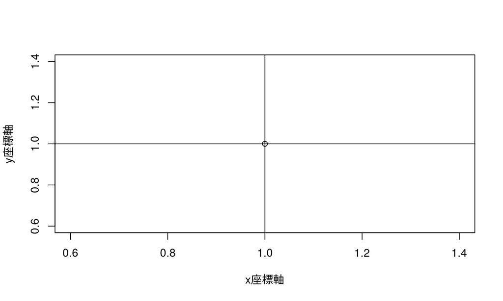

```r
plot(x = 1, y = 1, type = "p", xlab = "x座標軸", ylab = "y座標軸")
abline(v = 1)
abline(h = 1)
```

## 雕圖

- 繪圖相關功能繁複，要畫出漂亮的圖需要不停的「雕刻」

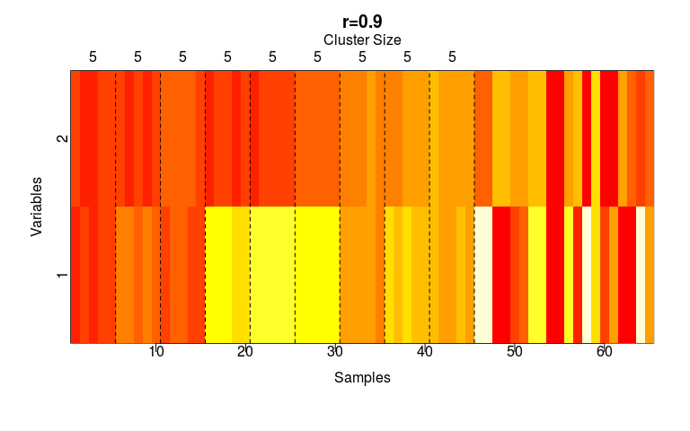

## 雕圖

```r
# ...
par() # 獲取現在的圖形做邊範圍
title(...) # 設定圖的標題
mtext(...) # 其他說明文字
abline(...) # 家住虛線
axis(...) # 修正座標軸
# ...
```

## 我是怎麼雕圖的?

- 平時多多累積圖庫相關知識
- 確定需求
  - 來自分析的需求: 說清楚
  - 來自美感的需求
- Google Google Google

## 03-RVisualization-01-One-Variable-Visualization

- 如何呈現數據的教學
- 同時介紹多種基本繪圖的函數

## ggplot2

## 何謂gg?

- 請同學安裝ggplot2套件
- The Grammar of Graphics
- 多利用data.frame
- 利用圖層的概念設計繪圖函數
- 具備`theme`的概念，能夠快速套用別人雕好的設定

## 構成圖形的要素

- x-y plot:
  - x 座標
  - y 座標
- 還有嘛?

## 問ggplot2

```r
library(ggplot2)
?geom_point
```

## Aesthetics

- **x**
- **y**
- alpha
- color
- fill
- group
- shape
- size
- stroke

## ggplot

```r
g <- ggplot(data = cars, aes(x = speed, y = dist))
```

- 以data.frame為主
- 繪圖的向量來自於data.frame的欄位
  - x: `cars$speed`
  - y: `cars$dist`
- 定義座標的同時不用定義繪圖動作

## x-y scatter plot

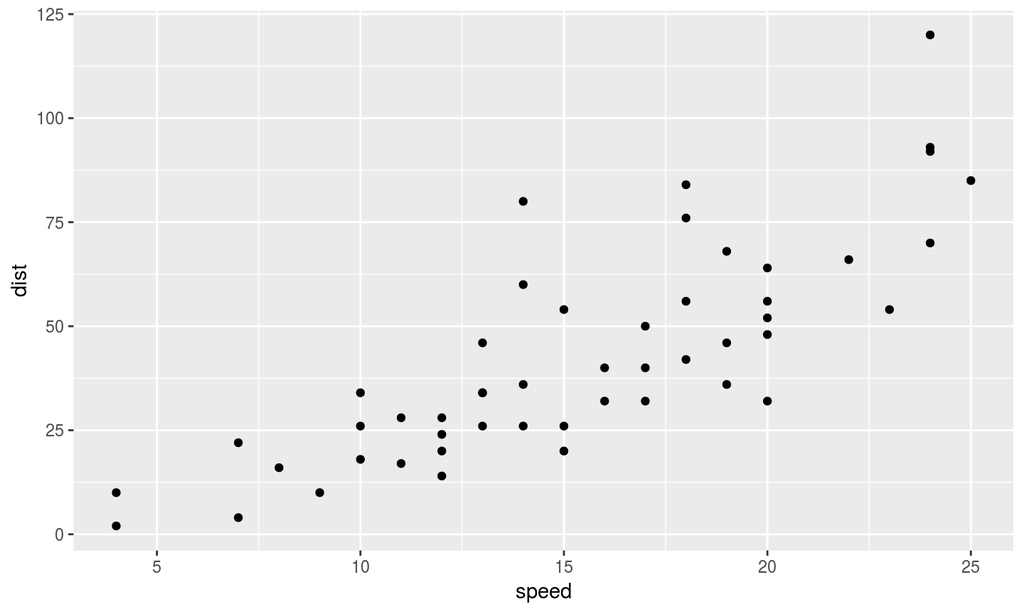

```r
g + geom_point()
```

- `+`代表添加圖層

## theme

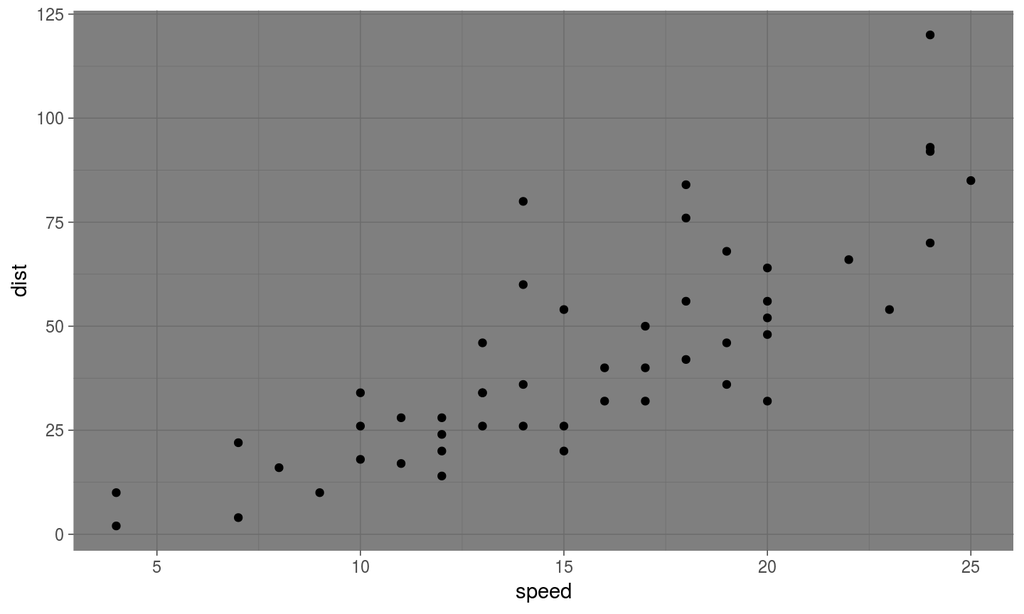

```r
g + geom_point() +
  theme_dark()
```

## ggplot2 的撰寫心得

1. 建立data.frame，整理好資料的欄位
2. 利用data.frame建立`gg`、`ggplot`物件
   - 標記共通的`aes`
3. 利用`+`添增圖片的物件與設定
4. `print`方法可以將`gg`、`ggplot`物件轉換成圖片

## 如何精進ggplot2?

- 多多學習他人的範例
- 多多練習與雕圖
- 瀏覽相關的套件

## Top 50 ggplot2 Visualizations

- http://r-statistics.co/Top50-Ggplot2-Visualizations-MasterList-R-Code.html

## 繪圖的目的

## 比較數據

- 初階的分析，在於過比較找出差異

## 範例一: iris

- 不同種類的花朵，生物特徵不同

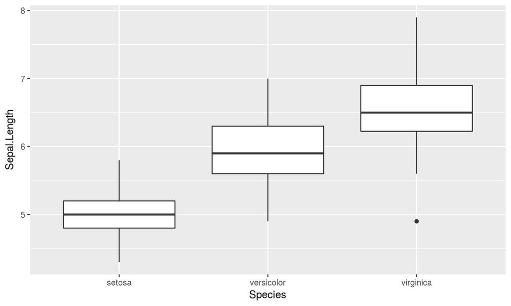

```r
ggplot(iris, aes(x = Species, y = Sepal.Length)) +
  geom_boxplot()
```

## 範例二: cars

- 速度不同，煞車後的滑行距離也不同

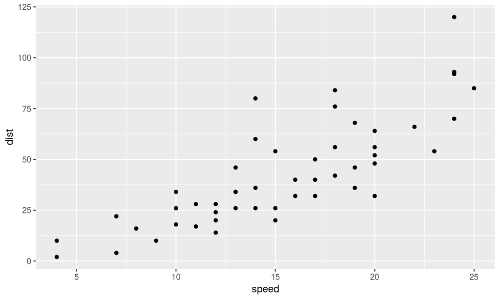

```r
ggplot(cars, aes(x = speed, y = dist)) +
  geom_point()
```

## 許多統計檢定的目的在於比較差異

- 隨機性會造成差異
  - 即使是相同的車速，煞車的滑行距離還是會變化
- 統計檢定: 分辨變化是不是來自隨機性
- 可以利用繪圖方法簡單比較

## 範例一: iris

- 請問setosa與versicolor的Sepal.Length的平均值是否有顯著差異
  - *請問setosa與versicolor的Sepal.Length的平均值的差異是否來自隨機性?*
  - *請問setosa與versicolor的Sepal.Length的平均值的差異是否顯著?*

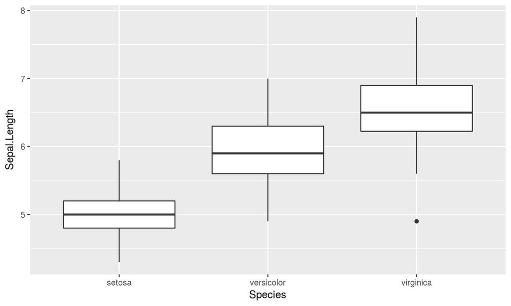

```r
ggplot(iris, aes(x = Species, y = Sepal.Length)) +
  geom_boxplot()
```